# Regression Model Project

Jason Liu

Oct 1, 2016

**Statement** This is the graduation project of Coursera course: Regression models, taught by JHU. The project can be viewed as a demonstration of regression techniques.

### Load Data and Related Packages

```r
library(datasets)
library(ggplot2)
library(GGally)
data(mtcars)
```

### Data Exploration

First step of regression analysis is to explore the dataset. With the built-in function ‘head’ we quickly have a look into th dataset.

```r
head(mtcars)
```

```
##                    mpg cyl disp  hp drat    wt  qsec vs am gear carb
## Mazda RX4         21.0   6  160 110 3.90 2.620 16.46  0  1    4    4
## Mazda RX4 Wag     21.0   6  160 110 3.90 2.875 17.02  0  1    4    4
## Datsun 710        22.8   4  108  93 3.85 2.320 18.61  1  1    4    1
## Hornet 4 Drive    21.4   6  258 110 3.08 3.215 19.44  1  0    3    1
## Hornet Sportabout 18.7   8  360 175 3.15 3.440 17.02  0  0    3    2
## Valiant           18.1   6  225 105 2.76 3.460 20.22  1  0    3    1
```

Subsquently, we plot the ‘pair plots’ of each variables in order to understand the correlations among different variables. (See Appendix) The variable,MPG, the abbreviation of ‘Mile per Gallon’, serves as the response variable of the model. Before ploting, we need to transfer two variables ‘vs’ and ‘am’ to the forms of factors as they do not have numeric meanings.

It is obvious that some variables are distributed discretely (i.e. cyl) while others are quite continous. The box plot is generated in order to briefly explore the oil consumptions of auto gear and mannual gear cars.

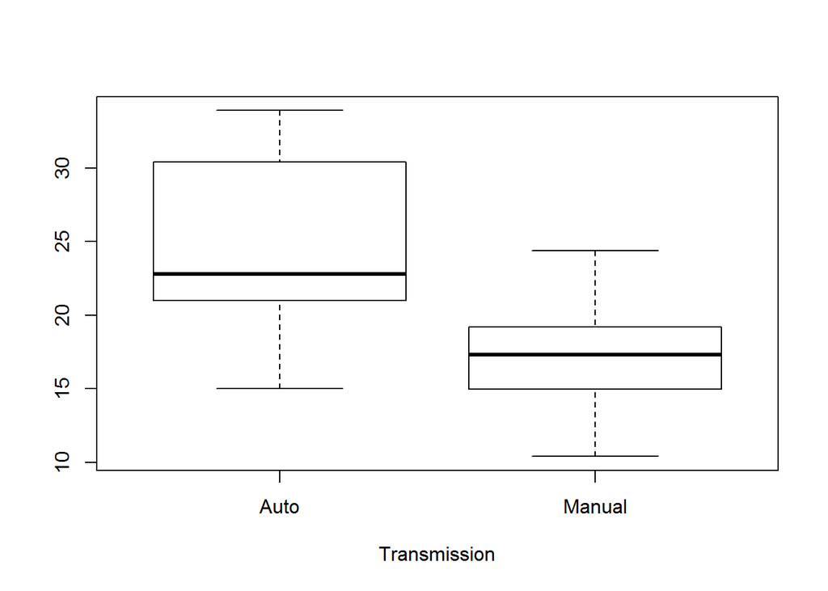

```r
tmpData<-mtcars[,c(1,9)]
tmpData$am<-ifelse(tmpData$am=='1',tmpData$am<-'Auto',tmpData$am<-'Manual')
boxplot(mpg ~ am, data = tmpData, xlab = "Transmission")
```